# module1

## Basic Biostatistics Concepts

This tutorial gives an overview of the numerical and visual summarization of continuous data outcomes, both for single samples and for comparing two (or more) samples.

After completing it, you will be able to do the following:

- Compute a sample mean and standard deviation
- Interpret the estimated mean, standard deviation, median and various percentiles computed for a sample of data
- Utilize histograms and boxplots to visualize the distributions of samples of continuous data
- Identify key summary statistics on the boxplot
- List and describe basic characteristics of some common distribution shapes for continuous data
- Recognize that a random sample taken from a larger population will (imperfectly) mimic the characteristics of the larger population
- Recognize the distribution of values in a random sample should reflect the distribution of the values in the population from which the sample was taken
- Explain why sample size does not systematically decrease or increase sample summary statistic estimates
- Recognize that while sample size does not systematically decrease or increase sample summary statistic estimates, the estimates become less variable with larger samples
- Suggest graphical approaches to comparing distributions of continuous data between two or more samples
- Explain why a difference in sample means can be used to quantify, in a single number summary, differences in distributions of continuous data

#### Sample Mean

$$\bar x = \frac{1}{N}\sum_{i=1}^{N} x_i $$

Note:

- The influence of each individual data point decrease as the sample size increases
- The sample mean is very sensitive to extreme values.

#### Sample Median

This is the middle value after the sample has been sorted from smallest to largest. It's also called the 50th percentile. e.g. 20, 65, **70**, 90, 110 has a median of **70**.

- Unlike the mean, the median is not sensitive to extreme values

#### Sample variance

$$s^2 = \frac{1}{N-1}\sum_{i=1}^{N} (x_i-\bar x)^2 $$

- $s^2$ is the unbiased estimate of the population variance $\sigma^2$
- **Why do we divide by N-1?** -Note that in principle, $s^2$ should measure the deviation from the poplulation mean $\mu$, which we donot know. We divide by N-1 to account for underestimation.

```python
import matplotlib.pyplot as plt
import pandas as pd
import numpy as np
import urllib
%matplotlib inline
```

```python
hospital_data = pd.read_csv("HOSPITAL.txt")
hospital_data.columns = [name.replace("'","") for name in hospital_data.columns]
hospital_data.head()
```

|  | Id | Dur_stay | Age | Sex | Temp | WBC | Antibio | Bact_cul | Service |
| --- | --- | --- | --- | --- | --- | --- | --- | --- | --- |
| 0 | 1 | 5 | 30 | 2 | 99.0 | 8 | 2 | 2 | 1 |
| 1 | 2 | 10 | 73 | 2 | 98.0 | 5 | 2 | 1 | 1 |
| 2 | 3 | 6 | 40 | 2 | 99.0 | 12 | 2 | 2 | 2 |
| 3 | 4 | 11 | 47 | 2 | 98.2 | 4 | 2 | 2 | 2 |
| 4 | 5 | 5 | 25 | 2 | 98.5 | 11 | 2 | 2 | 2 |

```python
print("sample mean for hospital duration = {:4.2f}".format(hospital_data['Dur_stay'].mean()))
```

```
sample mean for hospital duration = 8.60
```

```python
print("sample standard deviation for hospital duration = {:4.2f}".format(hospital_data['Dur_stay'].std()))
```

```
sample standard deviation for hospital duration = 5.72
```

```python
print("sample median for hospital duration = {:4.2f}".format(hospital_data['Dur_stay'].median()))
```

```
sample median for hospital duration = 8.00
```

The above value means that about 50% of all recorded hospital stays are less than 8 days.

### Five Number Summary Statistics

```python
summary = hospital_data['Dur_stay'].describe().loc[['min','max','25%','50%','75%']]
summary
```

```
min     3.0
max    30.0
25%     5.0
50%     8.0
75%    11.0
Name: Dur_stay, dtype: float64
```

The **five number summary** gives the minimum, the maximum, the first quartile (25th percentile, Q1), the second quartile (50th percentile, Q2) and the third quartile (75th percentile, Q3). From the above summary we see that

- 25% of all recorded hospital stay duration is less than or equal to 5 days
- 50% of all recorded hospital stay duration is less than or equal to 8 days
- 75% of all recorded hospital stay duration is less than or equal to 11 days

### Interquartile Range IQR

This is the difference between the third quartile and the first quartile. The IQR can be used

- as a measure of statistical dispersion
- to detect outliers in the data. Outliers are observations that fall below Q1 − 1.5 IQR or above Q3 + 1.5 IQR.

```python
IQR = summary.loc["75%"] - summary.loc["25%"]
print("The interquartile range is: {:4.2f}".format(IQR))
```

```
The interquartile range is: 6.00
```

### Box Plot

The Box Plot is a convenient way to view 5-number summary statistics.

```
Text(0,0.5,'days')
```

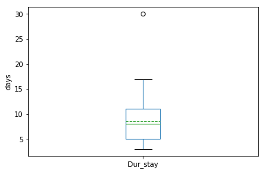

```python
hospital_data['Dur_stay'].plot(kind='box', whis=1.5, meanline=True, showmeans = True)
plt.ylabel('days')
```

The above Box plot shows the min, the max and the 3 quartiles. The circle point at the top around 30 falls above Q3+whis*IQR (whis=1.5 in this case). Hence this point is considered an outlier and plotted as open symbol.

```
Text(0,0.5,'days')
```

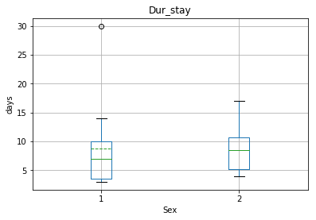

```python
hospital_data.boxplot('Dur_stay', by='Sex', whis=1.5, meanline=True, showmeans = True)
plt.suptitle('')
plt.ylabel('days')
```

The boxplot is also a convenient way to compare two groups. In the example above, it's clear that the median duration of hospital stay amount females (sex=1) is less than the median among males (sex=2)

### Misconception!

- The larger the sample size, the more normal the distribution becomes
- The larger the sample size, the smaller the deviation between individual sample points

**Note**: Sample size does not affect the estimates (mean, standard deviation). i.e. if the sample is truly representative of the population, then the sample mean $\bar x$ should be close to the population mean $\mu$ and hence should not depend on the sample size. However, the larger the sample, the smaller the variation between the estimates. In other words, 5 random samples of size 10 will have a higher standard deviation than 5 random samples of size 10000.

```python
dict={'N=20':[0,0,0,0,0],'N=200':[0,0,0,0,0],'N=500':[0,0,0,0,0],'N=1000':[0,0,0,0,0]}
df = pd.DataFrame(dict)
df.columns = ['N=5','N=20','N=500','N=1000']
df
```

|  | N=5 | N=20 | N=500 | N=1000 |
| --- | --- | --- | --- | --- |
| 0 | 0 | 0 | 0 | 0 |
| 1 | 0 | 0 | 0 | 0 |
| 2 | 0 | 0 | 0 | 0 |
| 3 | 0 | 0 | 0 | 0 |
| 4 | 0 | 0 | 0 | 0 |

```python
def get_std(df,col, n=20):
    for i in df.index:
        sample_std = np.random.normal(loc=10,scale=5, size=n).std()
        df.at[i,col] = sample_std
    return df
```

```python
get_std(df,'N=5',5)
get_std(df,'N=20',20)
get_std(df,'N=500',500)
get_std(df,'N=1000',1000)
```

|  | N=5 | N=20 | N=500 | N=1000 |
| --- | --- | --- | --- | --- |
| 0 | 5 | 5 | 4 | 5 |
| 1 | 4 | 4 | 4 | 4 |
| 2 | 3 | 3 | 4 | 4 |
| 3 | 4 | 4 | 4 | 5 |
| 4 | 7 | 3 | 4 | 5 |

**Note:** that there is no systematic relation between sample size and the estimated standard deviations (looking across the rows). But looking at the variations within the samples, we see that there is more variation within the samples with smaller size.